# Single vs Multi-Context Comparison (sc vs mc)

2025-12-09

## 1 1. Data Import

We use the file that contains **only model variants** with `_sc` and `_mc` suffixes.

```r
file_sc_mc <- "output_csvs/single_vs_multiple_context_grade_dist.csv"  # EDIT PATH IF NEEDED

raw_sc_mc <- readr::read_csv(file_sc_mc, show_col_types = FALSE)

glimpse(raw_sc_mc)
```

```
## Rows: 120
## Columns: 21
## $ ...1                <dbl> 0, 1, 2, 3, 4, 5, 6, 7, 8, 9, 10, 11, 12, 13, 14, …
## $ sonnet_sc           <dbl> 5.000000, 4.750000, 1.000000, 3.750000, 3.600000, …
## $ sonnet_mc           <dbl> 5.000000, 2.900000, 1.250000, 1.100000, 3.600000, …
## $ gemini_2.0_flash_sc <dbl> 4.583333, 1.350000, 1.250000, 1.333333, 1.333333, …
## $ gemini_2.0_flash_mc <dbl> 1.833333, 4.625000, 1.916667, 1.700000, 1.125000, …
## $ gemini_2.5_pro_sc   <dbl> 5.000000, 4.750000, 1.083333, 1.000000, 1.083333, …
## $ gemini_2.5_pro_mc   <dbl> 5.000000, 5.000000, 1.916667, 1.700000, 1.750000, …
## $ chatgpt4o_sc        <dbl> 5.000000, 4.750000, 1.333333, 1.000000, 1.250000, …
## $ chatgpt4o_mc        <dbl> 4.500000, 4.583333, 1.350000, 3.500000, 3.416667, …
## $ gpt4.1_sc           <dbl> 5.000000, 4.750000, 1.000000, 1.000000, 1.250000, …
## $ gpt4.1_mc           <dbl> 4.583333, 4.750000, 3.916667, 3.166667, 3.600000, …
## $ gpt4.1_images_sc    <dbl> 5.000000, 1.350000, 1.416667, 3.166667, 1.750000, …
## $ gpt4.1_images_mc    <dbl> 5.000000, 4.750000, 3.333333, 1.450000, 1.750000, …
## $ o3_sc               <dbl> 5.000000, 4.750000, 1.550000, 3.750000, 3.600000, …
## $ o3_mc               <dbl> 5.000000, 4.750000, 3.500000, 3.750000, 2.900000, …
## $ o3_pro_sc           <dbl> 5.000000, 4.750000, 3.416667, 3.000000, 3.833333, …
## $ o3_pro_mc           <dbl> 5.000000, 4.750000, 3.642857, 3.250000, 3.600000, …
## $ o4_mini_sc          <dbl> 5.000000, 4.750000, 1.166667, 1.333333, 1.250000, …
## $ o4_mini_mc          <dbl> 5.000000, 4.750000, 3.916667, 1.000000, 1.666667, …
## $ o4_mini_med_sc      <dbl> 5.000000, 4.750000, 1.916667, 1.750000, 1.833333, …
## $ o4_mini_med_mc      <dbl> 5.000000, 4.750000, 1.083333, 3.166667, 1.083333, …
```

Assumptions (based on the file):

- Column 1 (`Unnamed: 0`) is an **index** → we ignore it.
- Remaining columns are model variants of the form:
  - `modelname_sc`
  - `modelname_mc`

```r
# Drop the first index column
dat <- raw_sc_mc[, -1]

# Identify sc and mc columns
sc_cols <- names(dat)[str_ends(names(dat), "_sc")]
mc_cols <- names(dat)[str_ends(names(dat), "_mc")]

sc_cols
```

```
##  [1] "sonnet_sc"           "gemini_2.0_flash_sc" "gemini_2.5_pro_sc"
##  [4] "chatgpt4o_sc"        "gpt4.1_sc"           "gpt4.1_images_sc"
##  [7] "o3_sc"               "o3_pro_sc"           "o4_mini_sc"
## [10] "o4_mini_med_sc"
```

```r
mc_cols
```

```
##  [1] "sonnet_mc"           "gemini_2.0_flash_mc" "gemini_2.5_pro_mc"
##  [4] "chatgpt4o_mc"        "gpt4.1_mc"           "gpt4.1_images_mc"
##  [7] "o3_mc"               "o3_pro_mc"           "o4_mini_mc"
## [10] "o4_mini_med_mc"
```

We now extract **base model names** so we can pair `_sc` and `_mc` columns:

```r
# Helper to strip suffix
strip_suffix <- function(x, suffix) sub(paste0(suffix, "$"), "", x)

models_sc <- strip_suffix(sc_cols, "_sc")
models_mc <- strip_suffix(mc_cols, "_mc")

# Models that appear in both sc and mc
common_models <- intersect(models_sc, models_mc)
common_models
```

```
##  [1] "sonnet"           "gemini_2.0_flash" "gemini_2.5_pro"   "chatgpt4o"
##  [5] "gpt4.1"           "gpt4.1_images"    "o3"               "o3_pro"
##  [9] "o4_mini"          "o4_mini_med"
```

## 2 2. Long Format for sc vs mc

We create a long table with columns:

- `model` – base model name (e.g., `"sonnet"`, `"o3"`)
- `context` – `"sc"` or `"mc"`
- `item_id` – row index (shared for sc & mc)
- `score` – numeric score

```r
# Build long data for all models
long_list <- lapply(common_models, function(m) {
  sc_name <- paste0(m, "_sc")
  mc_name <- paste0(m, "_mc")

  tibble(
    item_id = seq_len(nrow(dat)),
    model   = m,
    sc      = dat[[sc_name]],
    mc      = dat[[mc_name]]
  )
})

wide_sc_mc <- bind_rows(long_list)

# Convert to long context format
scores_long <- wide_sc_mc %>%
  pivot_longer(
    cols = c(sc, mc),
    names_to = "context",
    values_to = "score"
  )

scores_long
```

```
## # A tibble: 2,400 × 4
##    item_id model  context score
##      <int> <chr>  <chr>   <dbl>
##  1       1 sonnet sc       5
##  2       1 sonnet mc       5
##  3       2 sonnet sc       4.75
##  4       2 sonnet mc       2.9
##  5       3 sonnet sc       1
##  6       3 sonnet mc       1.25
##  7       4 sonnet sc       3.75
##  8       4 sonnet mc       1.1
##  9       5 sonnet sc       3.6
## 10       5 sonnet mc       3.6
## # ℹ 2,390 more rows
```

Quick summary: mean and SD in each condition for each model.

```r
summary_stats <- scores_long %>%
  group_by(model, context) %>%
  summarise(
    n    = n(),
    mean = mean(score, na.rm = TRUE),
    sd   = sd(score, na.rm = TRUE),
    median = median(score, na.rm = TRUE),
    .groups = "drop"
  )

summary_stats
```

```
## # A tibble: 20 × 6
##    model            context     n  mean    sd median
##    <chr>            <chr>   <int> <dbl> <dbl>  <dbl>
##  1 chatgpt4o        mc        120  2.21  1.28   1.58
##  2 chatgpt4o        sc        120  1.99  1.26   1.43
##  3 gemini_2.0_flash mc        120  1.88  1.09   1.42
##  4 gemini_2.0_flash sc        120  1.94  1.23   1.34
##  5 gemini_2.5_pro   mc        120  2.28  1.28   1.83
##  6 gemini_2.5_pro   sc        120  2.34  1.35   1.79
##  7 gpt4.1           mc        120  2.04  1.21   1.48
##  8 gpt4.1           sc        120  2.21  1.43   1.34
##  9 gpt4.1_images    mc        120  1.93  1.08   1.42
## 10 gpt4.1_images    sc        120  1.93  1.12   1.38
## 11 o3               mc        120  3.11  1.48   3.33
## 12 o3               sc        120  3.18  1.35   3.42
## 13 o3_pro           mc        120  3.30  1.40   3.6
## 14 o3_pro           sc        120  3.34  1.48   3.88
## 15 o4_mini          mc        120  2.87  1.48   2.66
## 16 o4_mini          sc        120  2.46  1.47   1.58
## 17 o4_mini_med      mc        120  2.62  1.52   1.87
## 18 o4_mini_med      sc        120  2.27  1.31   1.65
## 19 sonnet           mc        120  2.03  1.24   1.48
## 20 sonnet           sc        120  2.14  1.39   1.48
```

## 3 3. Visualizing sc vs mc

### 3.1 3.1 Boxplots per Model

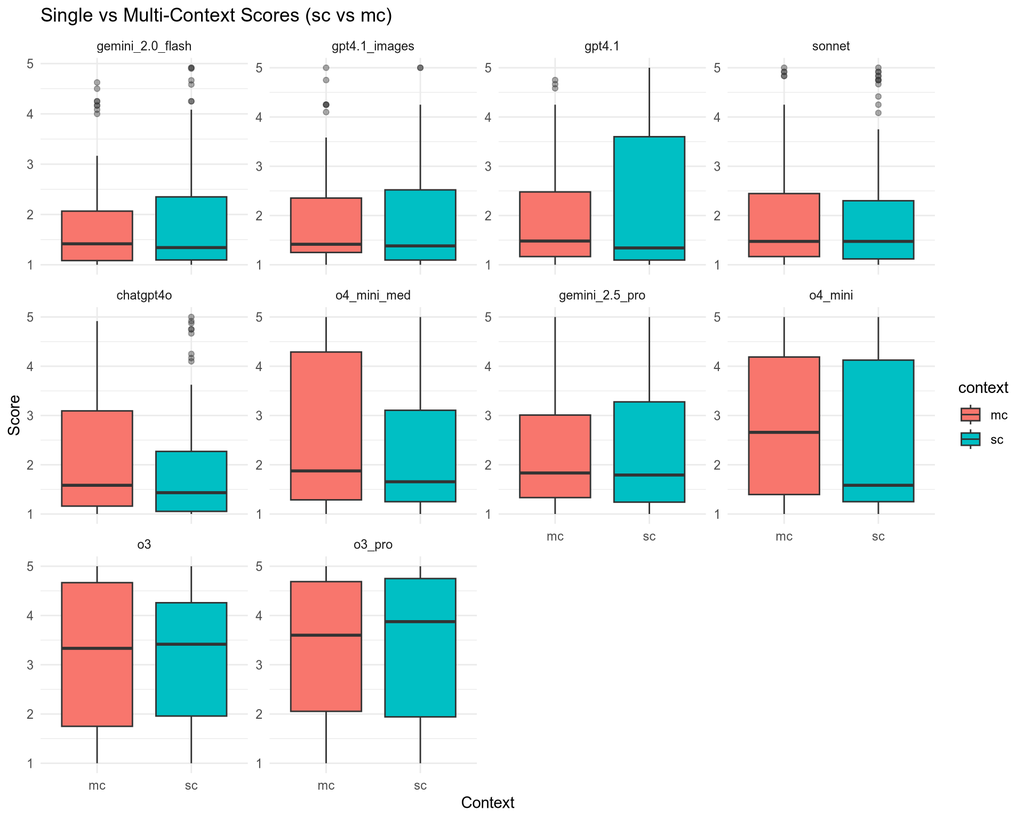

```r
scores_long %>%
  mutate(model = fct_reorder(model, score, .fun = median, na.rm = TRUE)) %>%
  ggplot(aes(x = context, y = score, fill = context)) +
  geom_boxplot(outlier.alpha = 0.4) +
  facet_wrap(~ model, scales = "free_y") +
  labs(
    title = "Single vs Multi-Context Scores (sc vs mc)",
    x = "Context",
    y = "Score"
  ) +
  theme_minimal()
```

### 3.2 3.2 Paired Differences (mc - sc)

We can also look at the **paired difference** per item:

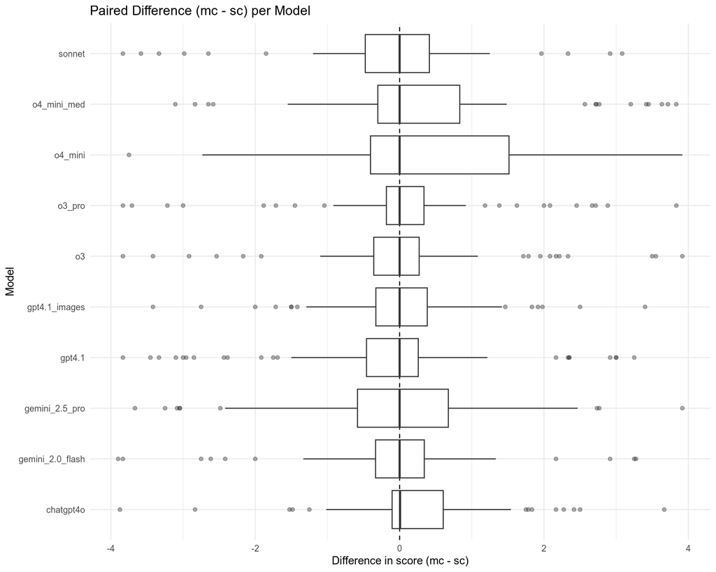

```r
diff_long <- wide_sc_mc %>%
  mutate(diff = mc - sc)

diff_long %>%
  ggplot(aes(x = model, y = diff)) +
  geom_hline(yintercept = 0, linetype = "dashed") +
  geom_boxplot(outlier.alpha = 0.4) +
  coord_flip() +
  labs(
    title = "Paired Difference (mc - sc) per Model",
    x = "Model",
    y = "Difference in score (mc - sc)"
  ) +
  theme_minimal()
```

Positive diff = multi-context > single-context on average. Negative diff = single-context > multi-context.

## 4 4. Paired Tests: sc vs mc within Each Model

Since scores are **paired by item** for sc and mc, we use the **Wilcoxon signed-rank test** (non-parametric paired test).

```r
paired_results <- purrr::map_df(
  common_models,
  ~{
    m <- .
    subdat <- wide_sc_mc %>% filter(model == m)

    # Paired Wilcoxon signed-rank test: is sc distribution different from mc?
    test <- wilcox.test(subdat$sc, subdat$mc, paired = TRUE, exact = FALSE)

    broom::tidy(test) %>%
      mutate(model = m)
  }
)

paired_results
```

```
## # A tibble: 10 × 5
##    statistic p.value method                                    alternative model
##        <dbl>   <dbl> <chr>                                     <chr>       <chr>
##  1      544.   0.765 Wilcoxon signed rank test with continuit… two.sided   sonn…
##  2      566.   0.983 Wilcoxon signed rank test with continuit… two.sided   gemi…
##  3      618.   0.858 Wilcoxon signed rank test with continuit… two.sided   gemi…
##  4      414.   0.115 Wilcoxon signed rank test with continuit… two.sided   chat…
##  5      653    0.508 Wilcoxon signed rank test with continuit… two.sided   gpt4…
##  6      614.   0.820 Wilcoxon signed rank test with continuit… two.sided   gpt4…
##  7      422.   0.712 Wilcoxon signed rank test with continuit… two.sided   o3
##  8      377    0.662 Wilcoxon signed rank test with continuit… two.sided   o3_p…
##  9      538    0.170 Wilcoxon signed rank test with continuit… two.sided   o4_m…
## 10      492    0.162 Wilcoxon signed rank test with continuit… two.sided   o4_m…
```

### 4.1 4.1 Multiple-Comparison Correction

We have one test per model; adjust p-values (Bonferroni + FDR):

```r
paired_results_adj <- paired_results %>%
  mutate(
    p_adj_bonferroni = p.adjust(p.value, method = "bonferroni"),
    p_adj_fdr        = p.adjust(p.value, method = "fdr")
  ) %>%
  arrange(p_adj_bonferroni)

paired_results_adj
```

```
## # A tibble: 10 × 7
##    statistic p.value method         alternative model p_adj_bonferroni p_adj_fdr
##        <dbl>   <dbl> <chr>          <chr>       <chr>            <dbl>     <dbl>
##  1      544.   0.765 Wilcoxon sign… two.sided   sonn…                1     0.954
##  2      566.   0.983 Wilcoxon sign… two.sided   gemi…                1     0.983
##  3      618.   0.858 Wilcoxon sign… two.sided   gemi…                1     0.954
##  4      414.   0.115 Wilcoxon sign… two.sided   chat…                1     0.568
##  5      653    0.508 Wilcoxon sign… two.sided   gpt4…                1     0.954
##  6      614.   0.820 Wilcoxon sign… two.sided   gpt4…                1     0.954
##  7      422.   0.712 Wilcoxon sign… two.sided   o3                   1     0.954
##  8      377    0.662 Wilcoxon sign… two.sided   o3_p…                1     0.954
##  9      538    0.170 Wilcoxon sign… two.sided   o4_m…                1     0.568
## 10      492    0.162 Wilcoxon sign… two.sided   o4_m…                1     0.568
```

### 4.2 4.2 Effect Sizes for Paired sc vs mc

```r
eff_results <- purrr::map_df(
  common_models,
  ~{
    m <- .
    subdat <- scores_long %>%
      filter(model == m)

    # Paired effect size: sc vs mc
    rstatix::wilcox_effsize(
      data = subdat,
      score ~ context,
      paired = TRUE
    ) %>%
      mutate(model = m)
  }
)

eff_results
```

```
## # A tibble: 10 × 8
##    .y.   group1 group2 effsize    n1    n2 magnitude model
##    <chr> <chr>  <chr>    <dbl> <int> <int> <ord>     <chr>
##  1 score mc     sc      0.0474    60    60 small     sonnet
##  2 score mc     sc      0.0272    59    60 small     gemini_2.0_flash
##  3 score mc     sc      0.0372    60    60 small     gemini_2.5_pro
##  4 score mc     sc      0.224     60    60 small     chatgpt4o
##  5 score mc     sc      0.0850    60    60 small     gpt4.1
##  6 score mc     sc      0.0407    58    60 small     gpt4.1_images
##  7 score mc     sc      0.0289   120    60 small     o3
##  8 score mc     sc      0.0902   120    60 small     o3_pro
##  9 score mc     sc      0.155     60    59 small     o4_mini
## 10 score mc     sc      0.167     60    60 small     o4_mini_med
```

### 4.3 4.3 Combined Summary

We now combine:

- medians in each condition
- mean paired difference (mc - sc)
- Wilcoxon stats
- adjusted p-values
- effect sizes

```r
# Compute mean/median per context + mean diff
diff_summary <- wide_sc_mc %>%
  group_by(model) %>%
  summarise(
    n_pairs   = n(),
    mean_sc   = mean(sc, na.rm = TRUE),
    mean_mc   = mean(mc, na.rm = TRUE),
    median_sc = median(sc, na.rm = TRUE),
    median_mc = median(mc, na.rm = TRUE),
    mean_diff = mean(mc - sc, na.rm = TRUE),   # mc - sc
    .groups   = "drop"
  )

summary_table <- paired_results_adj %>%
  select(model, statistic, p.value, p_adj_bonferroni, p_adj_fdr) %>%
  left_join(eff_results %>% select(model, effsize, magnitude), by = "model") %>%
  left_join(diff_summary, by = "model") %>%
  arrange(p_adj_bonferroni)

summary_table
```

```
## # A tibble: 10 × 13
##    model  statistic p.value p_adj_bonferroni p_adj_fdr effsize magnitude n_pairs
##    <chr>      <dbl>   <dbl>            <dbl>     <dbl>   <dbl> <ord>       <int>
##  1 sonnet      544.   0.765                1     0.954  0.0474 small         120
##  2 gemin…      566.   0.983                1     0.983  0.0272 small         120
##  3 gemin…      618.   0.858                1     0.954  0.0372 small         120
##  4 chatg…      414.   0.115                1     0.568  0.224  small         120
##  5 gpt4.1      653    0.508                1     0.954  0.0850 small         120
##  6 gpt4.…      614.   0.820                1     0.954  0.0407 small         120
##  7 o3          422.   0.712                1     0.954  0.0289 small         120
##  8 o3_pro      377    0.662                1     0.954  0.0902 small         120
##  9 o4_mi…      538    0.170                1     0.568  0.155  small         120
## 10 o4_mi…      492    0.162                1     0.568  0.167  small         120
## # ℹ 5 more variables: mean_sc <dbl>, mean_mc <dbl>, median_sc <dbl>,
## #   median_mc <dbl>, mean_diff <dbl>
```

## 5 5. Significance & Direction

Add a simple significance label and sign of effect:

```r
sig_table <- summary_table %>%
  mutate(
    significance = case_when(
      p_adj_bonferroni < 0.001 ~ "***",
      p_adj_bonferroni < 0.01  ~ "**",
      p_adj_bonferroni < 0.05  ~ "*",
      TRUE ~ "ns"
    ),
    direction = case_when(
      mean_diff >  0 ~ "mc > sc",
      mean_diff <  0 ~ "sc > mc",
      TRUE           ~ "no difference"
    )
  )

sig_table
```

```
## # A tibble: 10 × 15
##    model  statistic p.value p_adj_bonferroni p_adj_fdr effsize magnitude n_pairs
##    <chr>      <dbl>   <dbl>            <dbl>     <dbl>   <dbl> <ord>       <int>
##  1 sonnet      544.   0.765                1     0.954  0.0474 small         120
##  2 gemin…      566.   0.983                1     0.983  0.0272 small         120
##  3 gemin…      618.   0.858                1     0.954  0.0372 small         120
##  4 chatg…      414.   0.115                1     0.568  0.224  small         120
##  5 gpt4.1      653    0.508                1     0.954  0.0850 small         120
##  6 gpt4.…      614.   0.820                1     0.954  0.0407 small         120
##  7 o3          422.   0.712                1     0.954  0.0289 small         120
##  8 o3_pro      377    0.662                1     0.954  0.0902 small         120
##  9 o4_mi…      538    0.170                1     0.568  0.155  small         120
## 10 o4_mi…      492    0.162                1     0.568  0.167  small         120
## # ℹ 7 more variables: mean_sc <dbl>, mean_mc <dbl>, median_sc <dbl>,
## #   median_mc <dbl>, mean_diff <dbl>, significance <chr>, direction <chr>
```

## 6 6. Visual: Effect Size vs Adjusted p-value

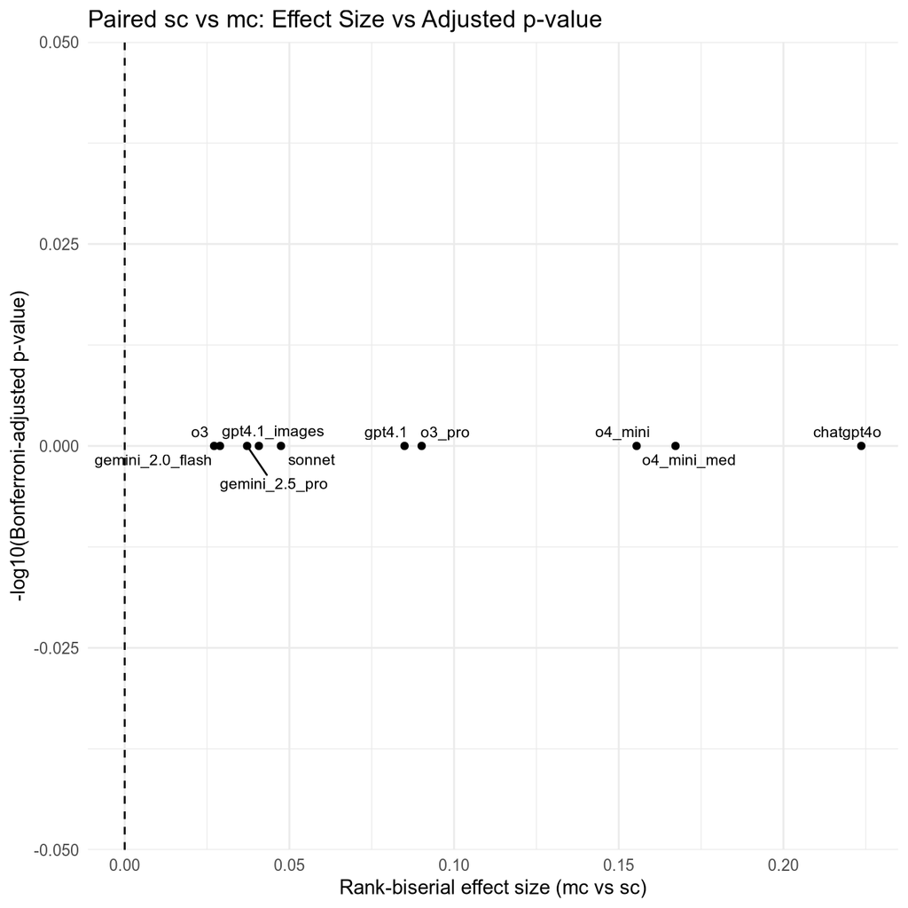

```r
sig_table %>%
  ggplot(aes(
    x = effsize,
    y = -log10(p_adj_bonferroni),
    label = model
  )) +
  geom_point() +
  ggrepel::geom_text_repel(size = 3, max.overlaps = 20) +
  geom_vline(xintercept = 0, linetype = "dashed") +
  labs(
    title = "Paired sc vs mc: Effect Size vs Adjusted p-value",
    x = "Rank-biserial effect size (mc vs sc)",
    y = "-log10(Bonferroni-adjusted p-value)"
  ) +
  theme_minimal()
```

### 6.1 Interpretation Notes

This gives you exactly what you asked for: a test of whether **single-context can be treated as independent / equivalent to multi-context**, per model.